# TCC Michele Mottin e Maria Fernanda

Michele Mottin, Maria Fernanda e [Henrique Laureano](https://henriquelaureano.github.io/)

Last modification on* 2021-11-12 17:51:04

> Como são 98 idosos (muito próximo de 100), as contagens são todas apresentadas unicamente em termos de percentuais.

# Queda & medo de cair

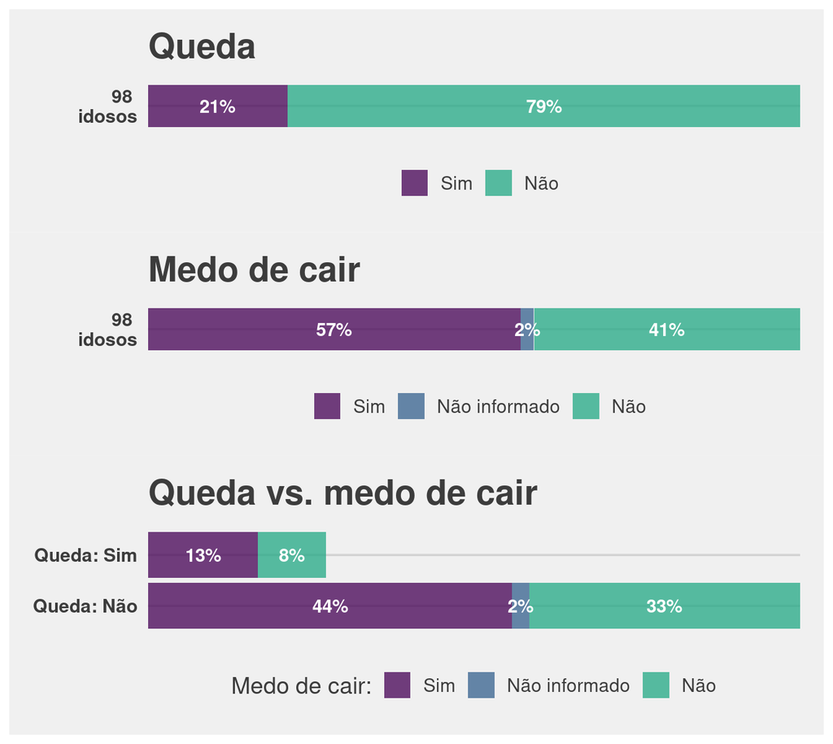

# Com que mora

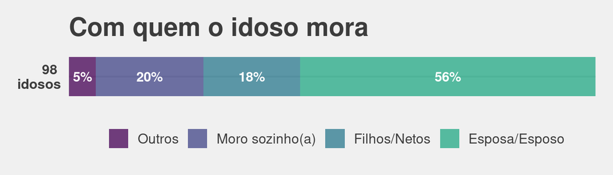

# Frequência de exercício físico

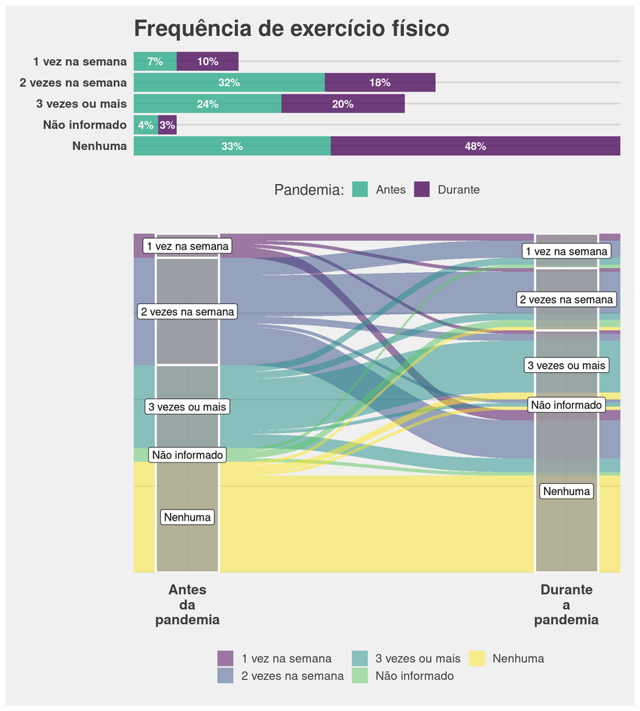

> O gráfico acima é chamado de gráfico de fluxo. Ele mostra, em termos de fluxo, a mudança de comportamento dos idosos na frequência de exercício físico de antes, para durante a pandemia.

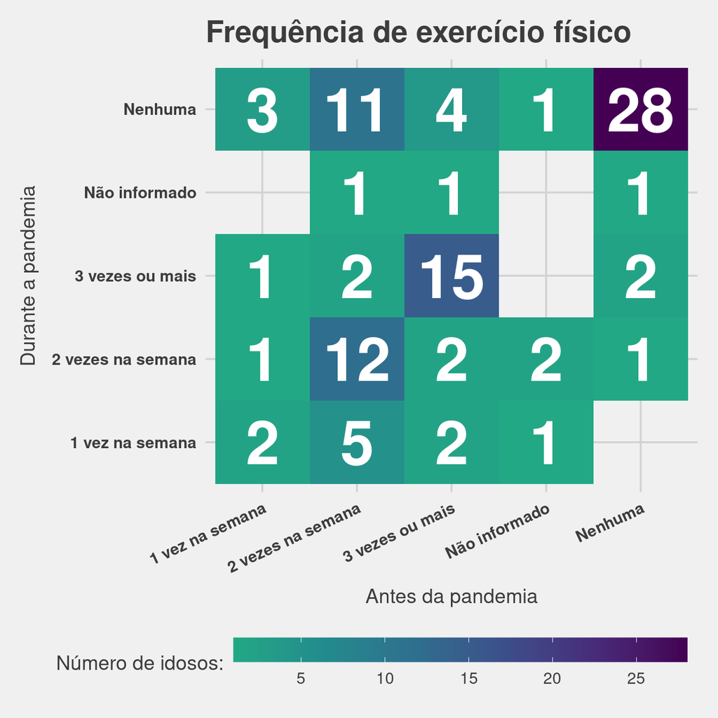

# Idade

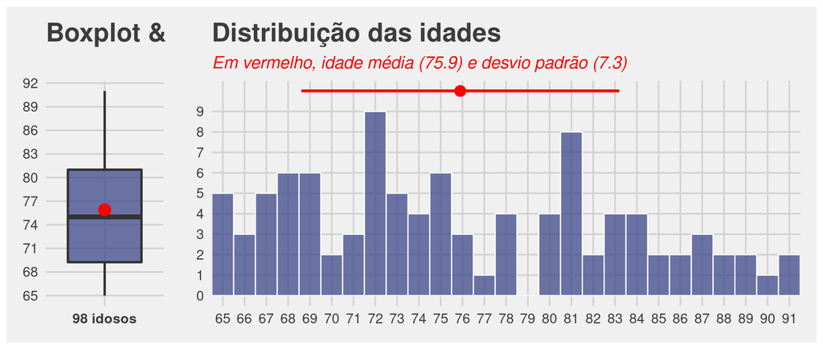

# Moradia

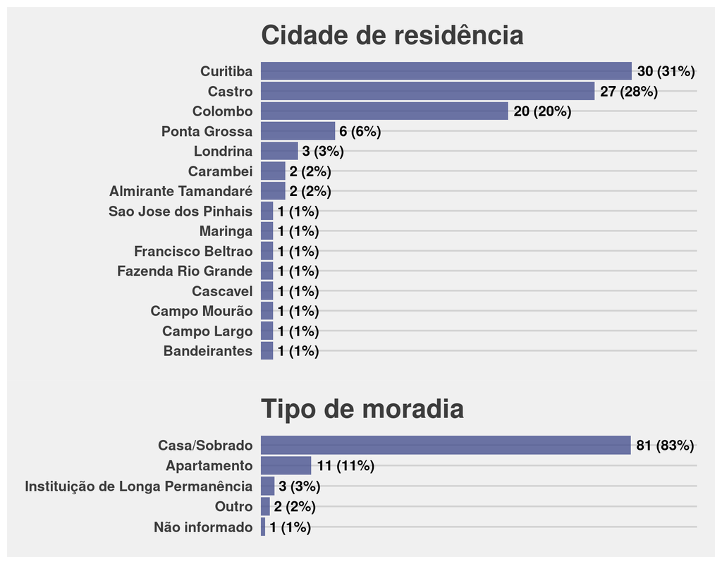

# Dores

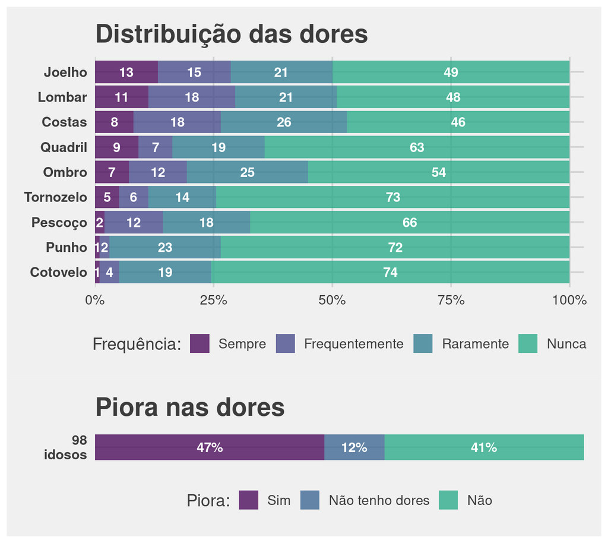

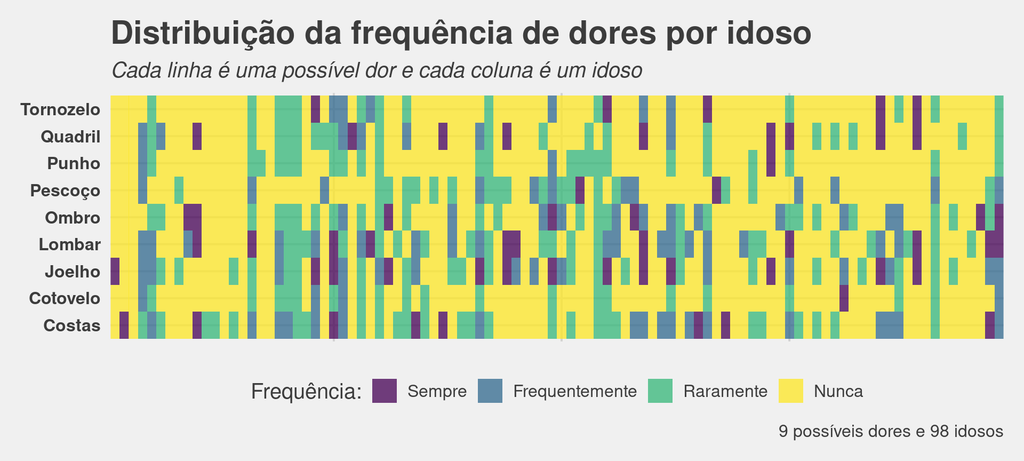

# Emoções

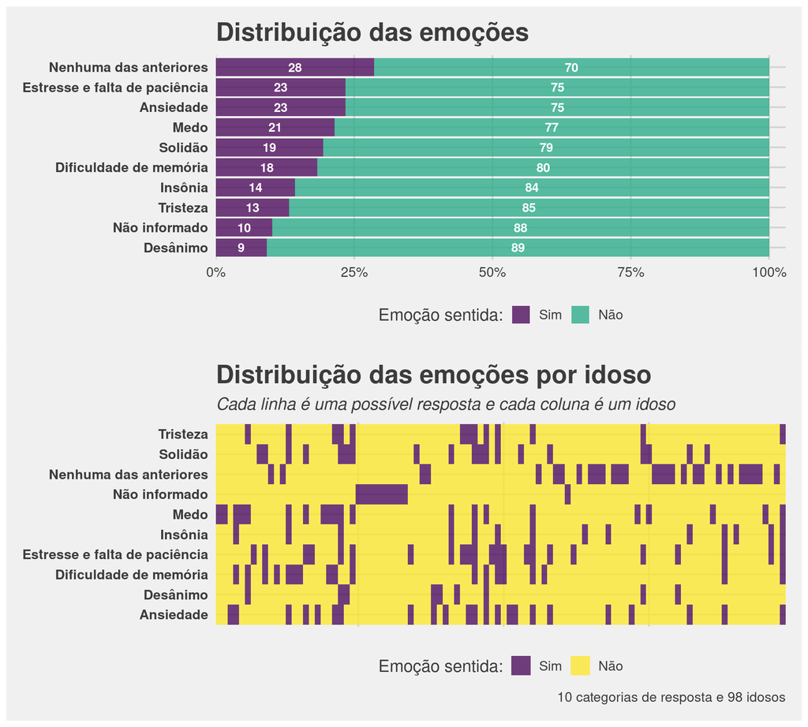

# Emoções por sexo

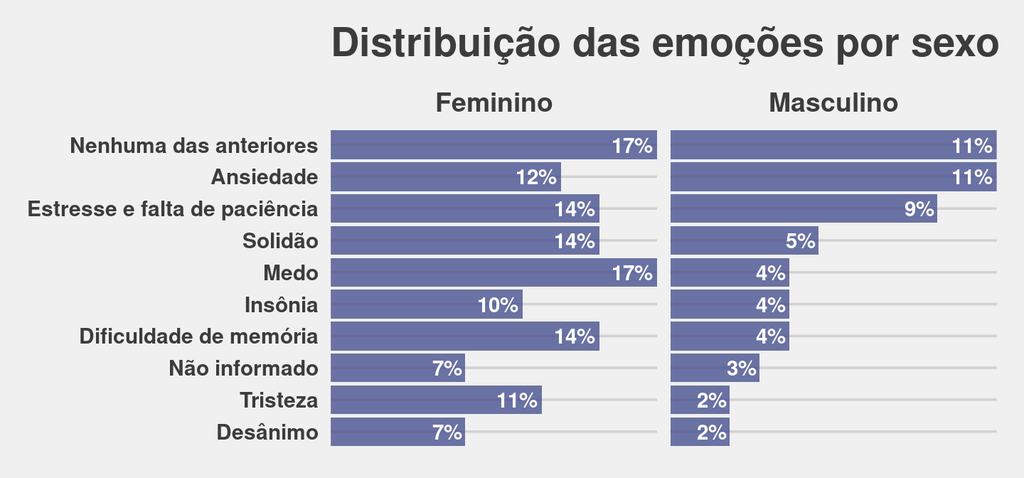

| sexo | Desânimo | Tristeza | Não informado | Dificuldade de memória | Insônia | Medo | Solidão | Estresse e falta de paciência | Ansiedade | Nenhuma das anteriores |
| --- | --- | --- | --- | --- | --- | --- | --- | --- | --- | --- |
| Feminino | 7 | 11 | 7 | 14 | 10 | 17 | 14 | 14 | 12 | 17 |
| Masculino | 2 | 2 | 3 | 4 | 4 | 4 | 5 | 9 | 11 | 11 |

```
    Fisher's Exact Test for Count Data with simulated p-value (based on 2000 replicates)

data:  dplyr::select(datemo_sexo.table, !sexo)
p-value = 0.4993
alternative hypothesis: two.sided
```

> Usando um Teste Exato de Fisher obtemos um p-valor de 0.50, indicando que não existe uma diferença estatísticamente significativa entre os sexos feminimo e masculino, em termos das frequências de emoções sentidas.

# Emoções por freq de exercício físico

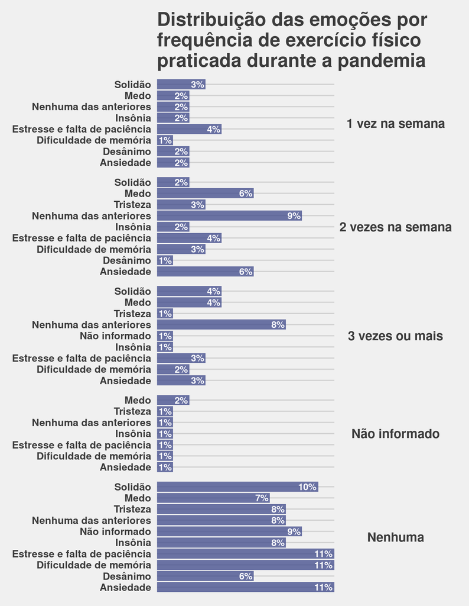

# Mudanças no corpo

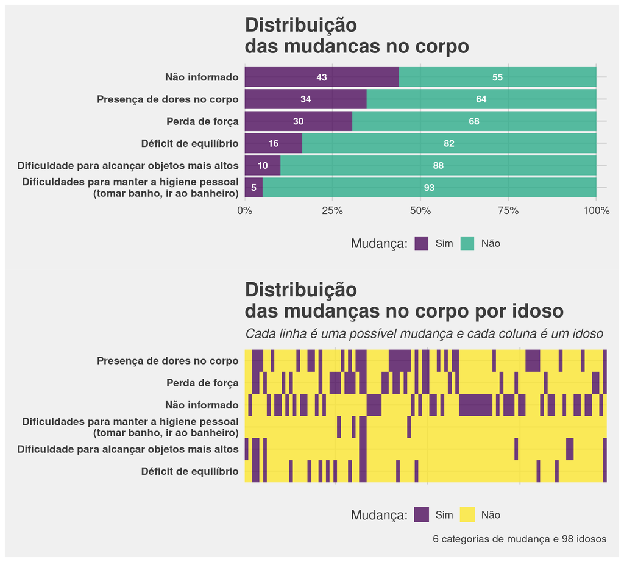

# Mudanças por freq de exercício físico

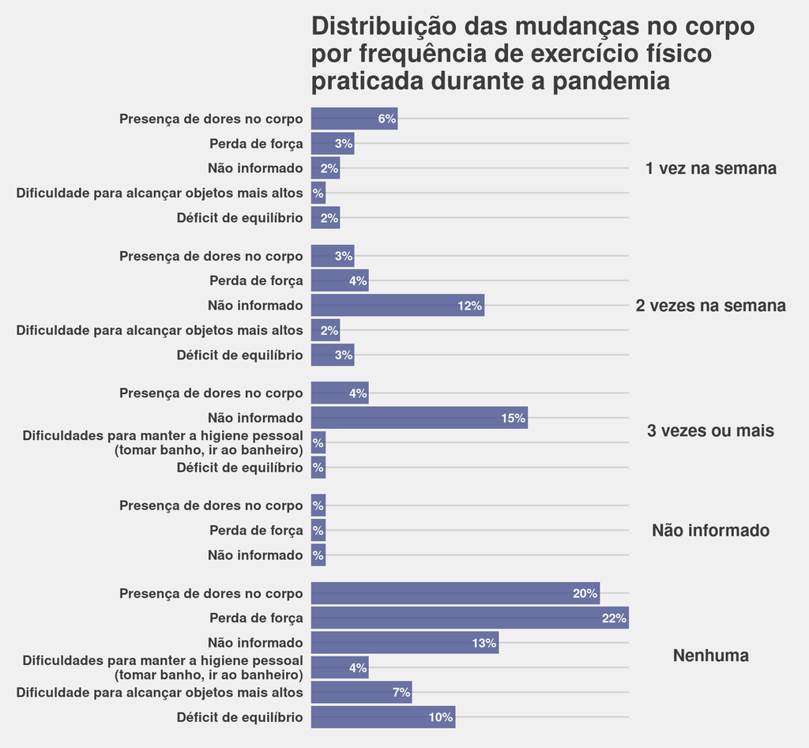

# Covid-19 & Comportamento

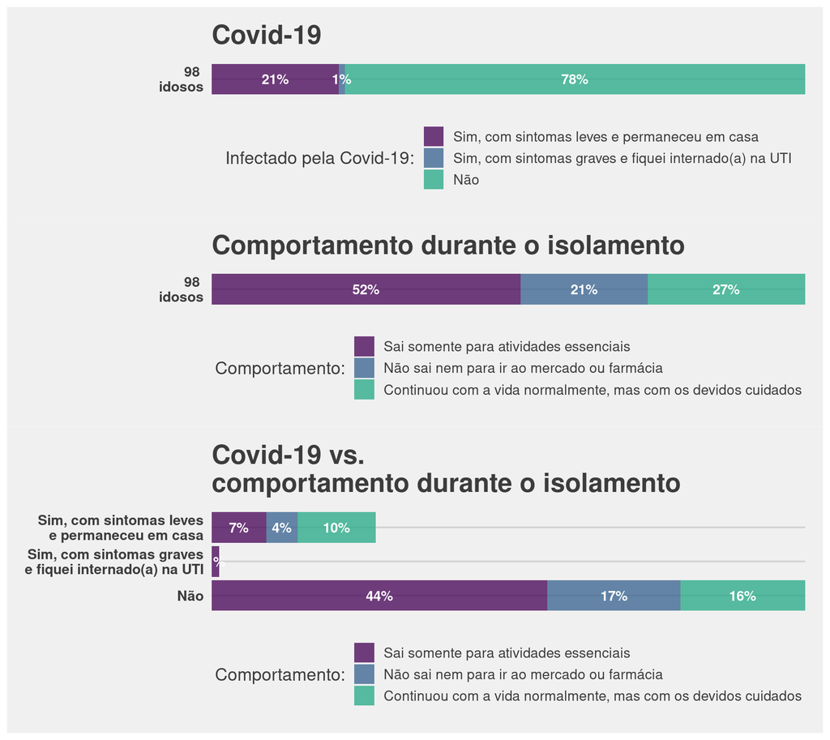

# Comorbidades

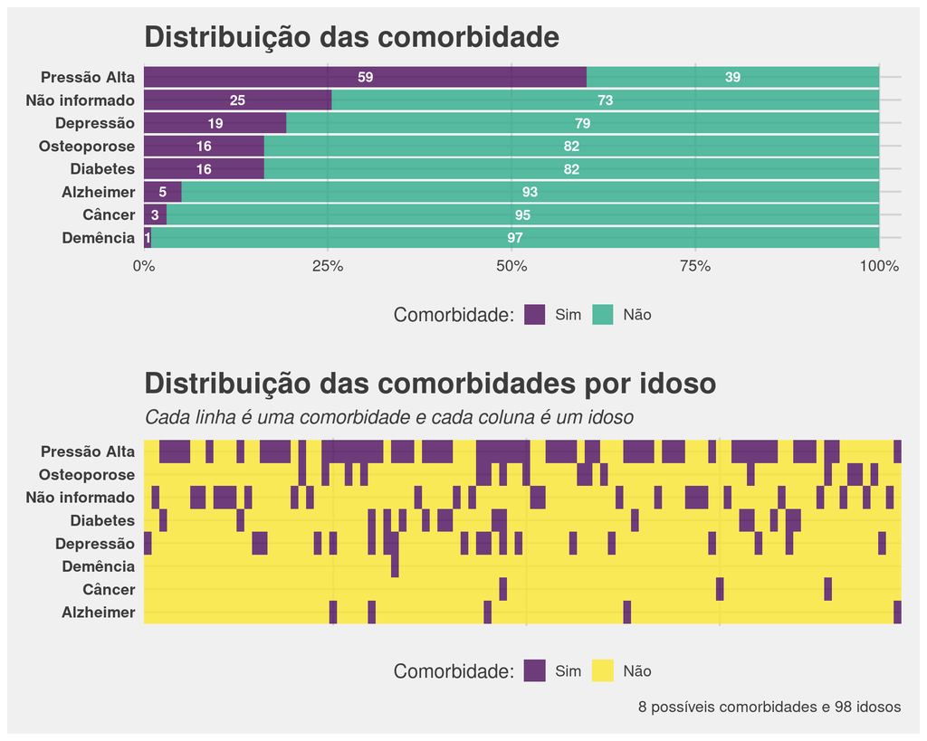

# Visita ao médico

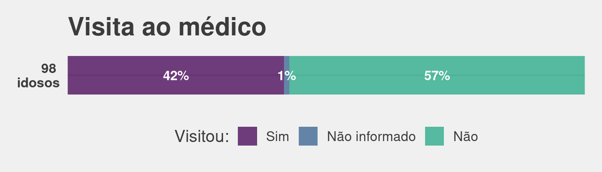

# Respondentes

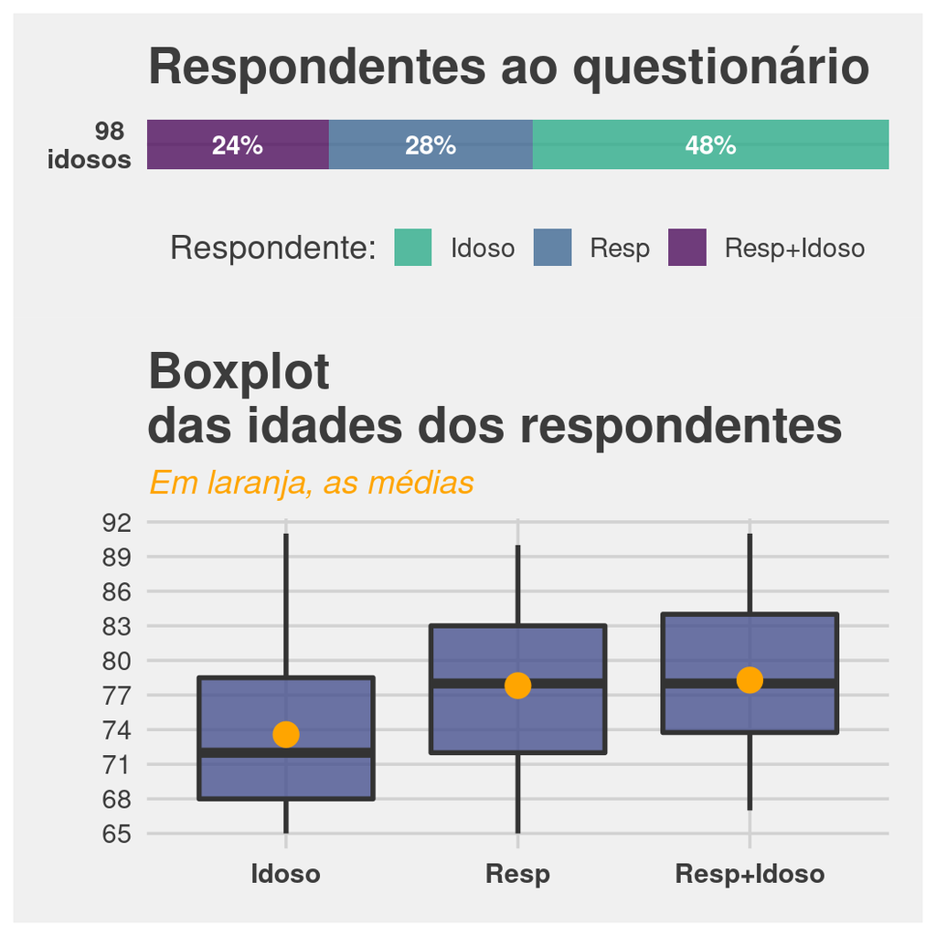

| respondente | n | mean | median | min | max |
| --- | --- | --- | --- | --- | --- |
| Idoso | 47 | 73.574 | 72 | 65 | 91 |
| Resp | 27 | 77.815 | 78 | 65 | 90 |
| Resp+Idoso | 24 | 78.292 | 78 | 67 | 91 |

```
Analysis of Variance Table

Response: dat$idade
                Df Sum Sq Mean Sq F value   Pr(>F)
dat$respondente  2  490.5 245.229   5.003 0.008594 **
Residuals       95 4656.5  49.016
---
Signif. codes:  0 '***' 0.001 '**' 0.01 '*' 0.05 '.' 0.1 ' ' 1
```

> A ANOVA acima indica que os grupos de respondentes diferem em termos da idade dos idosos (p-valor de 0.008594). Além disso, podemos comparar os grupos 2 a 2.

| Isso | vs | pvalue |
| --- | --- | --- |
| Idoso | Resp | 0.01827 |
| Idoso | Resp_Idoso | 0.00812 |
| Resp | Resp=Idoso | 0.81033 |

# Regressão logística

> Com uma regressão logística podemos ver quais são as variáveis mensuradas mais relevantes pro desfecho `queda` (sim ou não), aleḿ de ver pra quais delas existe diferença entre os seus níveis, em termos do desfecho `queda`.

> As variáveis que contém células em branco eu não utilizei, pois os grupos de `não informado` poderiam vir a ser significativo e a explicação disso não seria muito prática.

> Fiz dois modelos. 1) sem os locais de dor (eles, alguns deles, provavelmente ocorrem apenas em idosos que cairam. Isso desestabiliza o modelo fazendo com que nada mais seja significativo).E um 2) modelo que contém apenas os locais de dor (variáveis cada com 4 níveis).

> No primeiro modelo usamos:

```
 [1] "queda"                         "idade"                         "sexo"
 [4] "mora"                          "cuidador"                      "deitado.sentado"
 [7] "comportamento"                 "covid"                         "dores.piora"
[10] "Depressão"                     "Comorbidade.Nao informado"     "Diabetes"
[13] "Pressão Alta"                  "Osteoporose"                   "Alzheimer"
[16] "Demência"                      "Câncer"                        "Medo"
[19] "Ansiedade"                     "Insônia"                       "Dificuldade de memória"
[22] "Tristeza"                      "Desânimo"                      "Estresse e falta de paciência"
[25] "Solidão"                       "Nenhuma das anteriores"        "Emoção.Nao informado"
```

> A `queda` é a resposta/desfecho. `idade` é a única variável numérica. Da décima variável em diante temos as comorbidades seguidas das emoções (todas dicotômicas, sim ou não).

| Variavel | Estimate | Std. Error | z value | Pr(>\|z\|) | Chance | 2.5 % | 97.5 % |
| --- | --- | --- | --- | --- | --- | --- | --- |
| (Intercept) | -1.02611 | 0.49586 | -2.06936 | 0.03851 | 0.35840 | 0.12517 | 0.90290 |
| Depressão | 1.50058 | 0.69099 | 2.17165 | 0.02988 | 4.48430 | 1.18909 | 18.53792 |
| Medo | -3.60383 | 1.34129 | -2.68683 | 0.00721 | 0.02722 | 0.00097 | 0.23971 |
| Ansiedade | 1.23346 | 0.69026 | 1.78694 | 0.07395 | 3.43309 | 0.91708 | 14.23035 |
| `Dificuldade de memória` | 1.20887 | 0.85755 | 1.40967 | 0.15864 | 3.34969 | 0.65054 | 20.43232 |
| `Estresse e falta de paciência` | -1.55010 | 0.77415 | -2.00233 | 0.04525 | 0.21223 | 0.03929 | 0.86801 |
| `Nenhuma das anteriores` | -2.47457 | 1.11821 | -2.21297 | 0.02690 | 0.08420 | 0.00428 | 0.53741 |

> Após uma seleção de variáveis chegamos no modelo final que contém as variáveis acima. Ou seja, as variáveis mencionadas mais acima e que não constam nessa tabela, não foram estatísticamente significativas (na presença das outras) e saíram do modelo. Esse modelo final contém apenas 1 `comorbidade` e 5 `emoções`. Temos nessa tabela a estimativa das variáveis; uma medidade da incerteza inerente a essa estimativa (o erro padrão); o valor da sua estatística z; o famoso p-valor; a chance (razão de chance); e um intervalo de 95% pra chance.

> O próximo modelo é aquele que contém apenas as dores. Cada dor tem quatro níveis e o nunca foi o usado como nível de referência/intercepto.

| Variavel | Estimate | Std. Error | z value | Pr(>\|z\|) | Chance | 2.5 % | 97.5 % |
| --- | --- | --- | --- | --- | --- | --- | --- |
| (Intercept) | -1.913 | 0.609 | -3.142 | 0.002 | 1.480000e-01 | 0.037 | 4.310000e-01 |
| PescoçoRaramente | 4.344 | 1.411 | 3.080 | 0.002 | 7.704000e+01 | 7.326 | 2.666696e+03 |
| PescoçoFrequentemente | 1.512 | 1.179 | 1.283 | 0.200 | 4.538000e+00 | 0.382 | 4.817900e+01 |
| PescoçoSempre | 27.165 | 6250.163 | 0.004 | 0.997 | 6.276162e+11 | 0.000 | NA |
| OmbroRaramente | -3.434 | 1.868 | -1.838 | 0.066 | 3.200000e-02 | 0.000 | 5.920000e-01 |
| OmbroFrequentemente | -3.189 | 1.549 | -2.059 | 0.040 | 4.100000e-02 | 0.001 | 5.890000e-01 |
| OmbroSempre | -4.736 | 2.982 | -1.588 | 0.112 | 9.000000e-03 | 0.000 | 5.110000e-01 |
| PunhoRaramente | -3.336 | 1.521 | -2.194 | 0.028 | 3.600000e-02 | 0.001 | 4.800000e-01 |
| PunhoFrequentemente | -0.194 | 2.930 | -0.066 | 0.947 | 8.240000e-01 | 0.000 | 2.573860e+02 |
| PunhoSempre | 6.352 | 11047.582 | 0.001 | 1.000 | 5.738830e+02 | NA | Inf |
| CostasRaramente | 0.694 | 0.822 | 0.844 | 0.399 | 2.002000e+00 | 0.379 | 1.034000e+01 |
| CostasFrequentemente | 1.365 | 1.318 | 1.036 | 0.300 | 3.914000e+00 | 0.243 | 5.456900e+01 |
| CostasSempre | -19.953 | 2698.332 | -0.007 | 0.994 | 0.000000e+00 | NA | 5.329503e+63 |
| QuadrilRaramente | 0.066 | 1.124 | 0.059 | 0.953 | 1.068000e+00 | 0.100 | 9.342000e+00 |
| QuadrilFrequentemente | -1.947 | 1.963 | -0.992 | 0.321 | 1.430000e-01 | 0.002 | 6.184000e+00 |
| QuadrilSempre | -24.006 | 2529.877 | -0.009 | 0.992 | 0.000000e+00 | NA | 8.661699e+55 |
| TornozeloRaramente | 3.171 | 1.858 | 1.707 | 0.088 | 2.384100e+01 | 0.814 | 1.781095e+03 |
| TornozeloFrequentemente | 6.483 | 3.314 | 1.956 | 0.050 | 6.538030e+02 | 4.585 | 6.048871e+06 |
| TornozeloSempre | 7.637 | 3.081 | 2.479 | 0.013 | 2.072776e+03 | 10.824 | 3.655325e+06 |

> Pra tentar entender os resultados dessa tabela ajuda bastante ter o gráfico abaixo. Dos nove locais de dores, seis permaneceram no modelo. Pra alguns deles, o nível `sempre` tem um efeito muito grande e com uma incerteza maior ainda (levando isso para p-valores altos, não significativos). No gráfico podemos ver que isso acontece pois não temos idosos `sempre` com dor naquela região, nos dois grupos de queda (sim e ñão). Como não temos dados, a incerteza é gigantesca - levando pra chances também gigantescas.

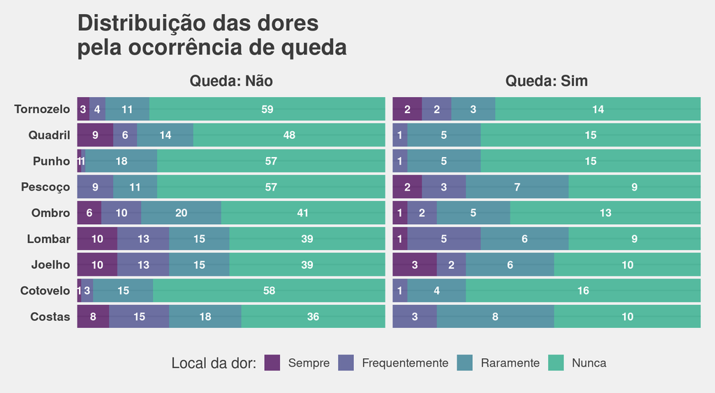

# Referência

> A análise estatística foi realizada no ambiente de computação estatística R (R Core Team, 2021). Para a descrição das variáveis quantitativas, diversas medidas resumo foram obtidas, como o cálculo dos principais quantis, médias, valores extremos, e desvios padrão. As variáveis e características qualitativas foram resumidas em termos do cálculo de frequências e percentuais, sendo visualizados através de gráficos de barra e frequência, além de mapas de intensidade. Uma regressão logística (um modelo linear generalizado binomial com função de ligação logit) (Hosmer & Lemeshow, 2000; Harrell, 2015) foi utilizada para selecionar as características mais associadas com o desfecho queda (sim ou não). A partir de tal modelo razões de chance e seus intervalos de confiança foram computados. Os principais pacotes R utilizados foram o dplyr (Wickham et al., 2021), tidyr (Wickham, 2021), ggplot2 (Wickham, 2016), ggalt (Rudis et al., 2017), purrr (Henry & Wickham, 2020) e MASS (Venables & Ripley, 2002).

> R Core Team (2021). R: A language and environment for statistical computing. R Foundation for Statistical Computing, Vienna, Austria. URL https://www.R-project.org/

> Hosmer, David W.; Lemeshow, Stanley (2000). Applied Logistic Regression (2nd ed.). Wiley. ISBN 978-0-471-35632-5

> Harrell, Frank E. (2015). Regression Modeling Strategies. Springer Series in Statistics (2nd ed.). New York; Springer. doi:10.1007/978-3-319-19425-7. ISBN 978-3-319-19424-0

> Hadley Wickham, Romain François, Lionel Henry and Kirill Müller (2021). dplyr: A Grammar of Data Manipulation. R package version 1.0.7. https://CRAN.R-project.org/package=dplyr

> Hadley Wickham (2021). tidyr: Tidy Messy Data. R package version 1.1.3. https://CRAN.R-project.org/package=tidyr

> Hadley Wickham (2016). ggplot2: Elegant Graphics for Data Analysis. Springer-Verlag New York

> Bob Rudis, Ben Bolker and Jan Schulz (2017). ggalt: Extra Coordinate Systems, ‘Geoms’, Statistical Transformations, Scales and Fonts for ‘ggplot2’. R package version 0.4.0. https://CRAN.R-project.org/package=ggalt

> Lionel Henry and Hadley Wickham (2020). purrr: Functional Programming Tools. R package version 0.3.4. https://CRAN.R-project.org/package=purrr

> Venables, W. N. & Ripley, B. D. (2002) Modern Applied Statistics with S. Fourth Edition. Springer, New York. ISBN 0-387-95457-0